# Red Wine Quality Analysis by Aaron Wilson

# Univariate Analysis

### What is the structure of your dataset?

> There are 1599 red wines in the dataset with 12 variables (fixed acidity, volatile acidity, citric acid, residual sugar, chlorides, free sulfur dioxide, total sulfur dioxide, density, pH, sulphates, alcohol, and quality). Other than quality all are objective measurements, while quality is rated by judge’s sensory data.

> Other Observations: - over 82% of red wines have a quality rating of 5-6. - Most wines have a density between .995 and 1. - Most wines have a sulphate between 0.4 and 0.8 - Most wines have a pH between 3.0 and 3.5 - Most wines have a volatile acidity between 0.3 and 0.8

### What is/are the main feature(s) of interest in your dataset?

> Quality is the main feature of the dataset and I would like to determine what features are best for predicting the quality rating. I suspect alcohol and volatile acid and what impacts them will be most telling.

### What other features in the dataset do you think will help support your investigation into your feature(s) of interest?

> I think alcohol and volitile acid contribut the most significantly to quality ratings, but sulphates, total sulfur dioxide, free sulfur dioxide, chlorides, residual sugar, citric acid, and volatile and fixed acidity all likely contribute.

### Did you create any new variables from existing variables in the dataset?

> I have not created any new variables.

### Of the features you investigated, were there any unusual distributions? Did you perform any operations on the data to tidy, adjust, or change the form of the data? If so, why did you do this?

> I used log10 scale for sulphates, total sulfur dioxide, and free sulfur dioxide. All three had a right skew and using log10 tranformed the variable into a normal distribution.

# Bivariate Plots Section

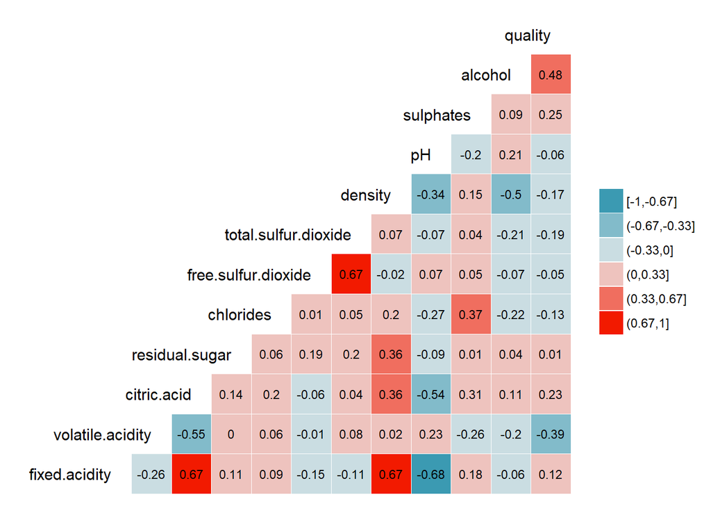

> There is a moderate uphill correlation between alcohol and quality and a weak downhill correlation between volatile acidity and quality.

> Sulphates have a weak uphill correlation with citric acid and chloride.

> pH has moderate downhill correlation to fixed acidity, citric acid and a weak downhill correlation with denisty.

> Density has a moderate uphill correlation with fixed acidity and weak uphill with citric acid and residual sugar

> Total sulfur dioxide and free sulfur dioxide have a moderate uphill correlation.

> Citric acid has a moderate downhill correlation with volatile acidity and a moderate uphill correlation with fixed acidity.

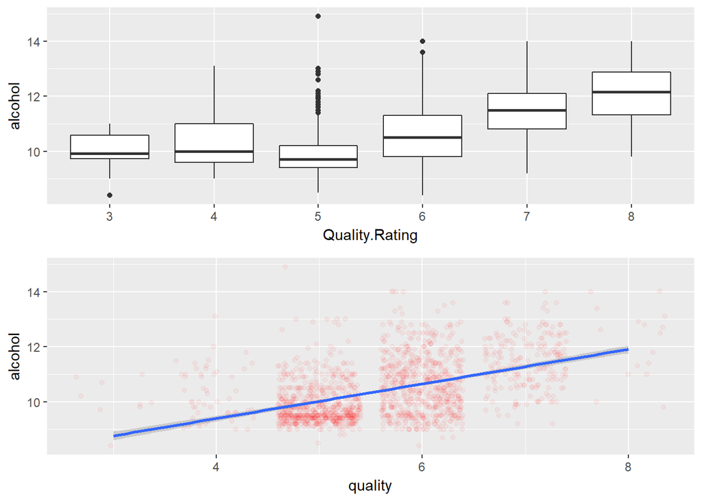

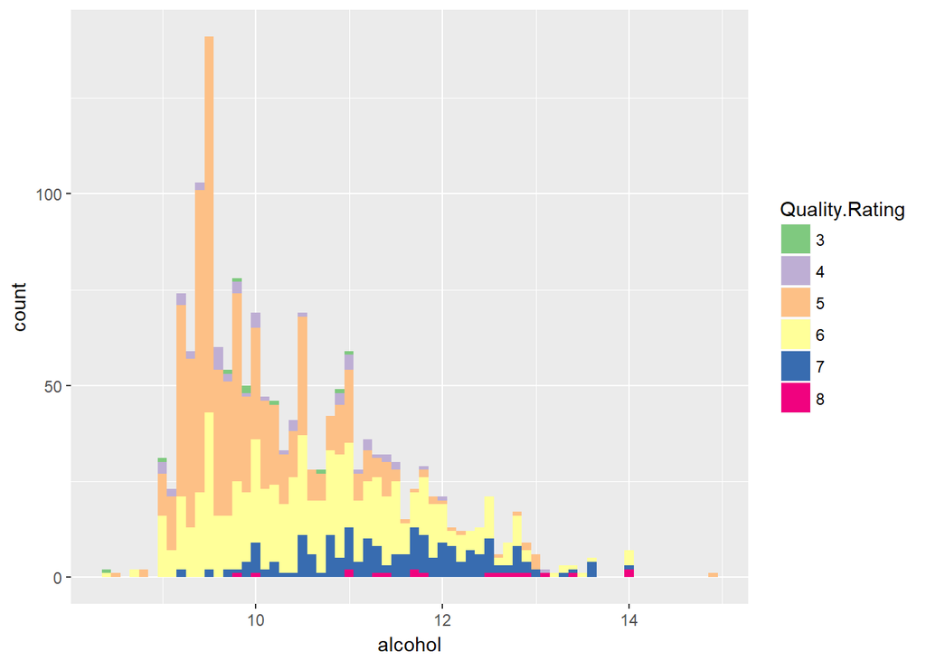

> The relationship between quality rating and alcohol amount in each wine is linear. The variance is highest at the 4, 6, and 8 quality ratings.

```
## df$quality: 3
##    Min. 1st Qu.  Median    Mean 3rd Qu.    Max.
##   8.400   9.725   9.925   9.955  10.575  11.000
## --------------------------------------------------------
## df$quality: 4
##    Min. 1st Qu.  Median    Mean 3rd Qu.    Max.
##    9.00    9.60   10.00   10.27   11.00   13.10
## --------------------------------------------------------
## df$quality: 5
##    Min. 1st Qu.  Median    Mean 3rd Qu.    Max.
##     8.5     9.4     9.7     9.9    10.2    14.9
## --------------------------------------------------------
## df$quality: 6
##    Min. 1st Qu.  Median    Mean 3rd Qu.    Max.
##    8.40    9.80   10.50   10.63   11.30   14.00
## --------------------------------------------------------
## df$quality: 7
##    Min. 1st Qu.  Median    Mean 3rd Qu.    Max.
##    9.20   10.80   11.50   11.47   12.10   14.00
## --------------------------------------------------------
## df$quality: 8
##    Min. 1st Qu.  Median    Mean 3rd Qu.    Max.
##    9.80   11.32   12.15   12.09   12.88   14.00
```

```
##
## Call:
## lm(formula = df$quality ~ df$alcohol)
##
## Residuals:
##     Min      1Q  Median      3Q     Max
## -2.8442 -0.4112 -0.1690  0.5166  2.5888
##
## Coefficients:
##             Estimate Std. Error t value Pr(>|t|)
## (Intercept)  1.87497    0.17471   10.73   <2e-16 ***
## df$alcohol   0.36084    0.01668   21.64   <2e-16 ***
## ---
## Signif. codes:  0 '***' 0.001 '**' 0.01 '*' 0.05 '.' 0.1 ' ' 1
##
## Residual standard error: 0.7104 on 1597 degrees of freedom
## Multiple R-squared:  0.2267, Adjusted R-squared:  0.2263
## F-statistic: 468.3 on 1 and 1597 DF,  p-value: < 2.2e-16
```

> For ratings of 5 through 8 the mean and median increase. The lower ratings are a bit higher than 5. There is probably another factor influence the lower rated wines, though it could be sample size. Using the R^2 value it appears alcohol explains about 22 percent of the variance in ratings.

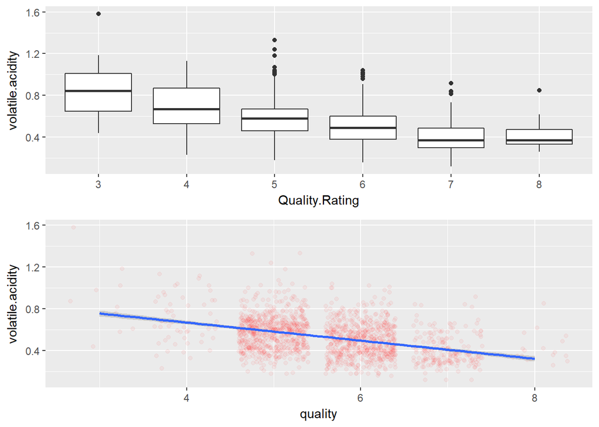

> The relationship between volatile acidity by quality rating is linear. As the boxes show there is very large variance in the 3 and 4 ratings.

```
## df$quality: 3
##    Min. 1st Qu.  Median    Mean 3rd Qu.    Max.
##  0.4400  0.6475  0.8450  0.8845  1.0100  1.5800
## --------------------------------------------------------
## df$quality: 4
##    Min. 1st Qu.  Median    Mean 3rd Qu.    Max.
##   0.230   0.530   0.670   0.694   0.870   1.130
## --------------------------------------------------------
## df$quality: 5
##    Min. 1st Qu.  Median    Mean 3rd Qu.    Max.
##   0.180   0.460   0.580   0.577   0.670   1.330
## --------------------------------------------------------
## df$quality: 6
##    Min. 1st Qu.  Median    Mean 3rd Qu.    Max.
##  0.1600  0.3800  0.4900  0.4975  0.6000  1.0400
## --------------------------------------------------------
## df$quality: 7
##    Min. 1st Qu.  Median    Mean 3rd Qu.    Max.
##  0.1200  0.3000  0.3700  0.4039  0.4850  0.9150
## --------------------------------------------------------
## df$quality: 8
##    Min. 1st Qu.  Median    Mean 3rd Qu.    Max.
##  0.2600  0.3350  0.3700  0.4233  0.4725  0.8500
```

```
##
## Call:
## lm(formula = df$quality ~ df$volatile.acidity)
##
## Residuals:
##      Min       1Q   Median       3Q      Max
## -2.79071 -0.54411 -0.00687  0.47350  2.93148
##
## Coefficients:
##                     Estimate Std. Error t value Pr(>|t|)
## (Intercept)          6.56575    0.05791  113.39   <2e-16 ***
## df$volatile.acidity -1.76144    0.10389  -16.95   <2e-16 ***
## ---
## Signif. codes:  0 '***' 0.001 '**' 0.01 '*' 0.05 '.' 0.1 ' ' 1
##
## Residual standard error: 0.7437 on 1597 degrees of freedom
## Multiple R-squared:  0.1525, Adjusted R-squared:  0.152
## F-statistic: 287.4 on 1 and 1597 DF,  p-value: < 2.2e-16
```

> There is lower mean volatile acidity with increase in quality rating, until quality rating of 8. It goes up slightly from 7, but this could be due to the low amount of wines at these ratings. Using R^2 volatile acidity is responsible for 15% of the variation in quality ratings.

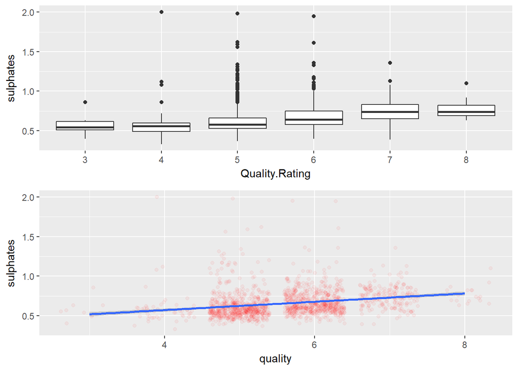

> Quality and sulphates have a linear relationship with the most variation in ratings 4 through 6.

```
## df$quality: 3
##    Min. 1st Qu.  Median    Mean 3rd Qu.    Max.
##  0.4000  0.5125  0.5450  0.5700  0.6150  0.8600
## --------------------------------------------------------
## df$quality: 4
##    Min. 1st Qu.  Median    Mean 3rd Qu.    Max.
##  0.3300  0.4900  0.5600  0.5964  0.6000  2.0000
## --------------------------------------------------------
## df$quality: 5
##    Min. 1st Qu.  Median    Mean 3rd Qu.    Max.
##   0.370   0.530   0.580   0.621   0.660   1.980
## --------------------------------------------------------
## df$quality: 6
##    Min. 1st Qu.  Median    Mean 3rd Qu.    Max.
##  0.4000  0.5800  0.6400  0.6753  0.7500  1.9500
## --------------------------------------------------------
## df$quality: 7
##    Min. 1st Qu.  Median    Mean 3rd Qu.    Max.
##  0.3900  0.6500  0.7400  0.7413  0.8300  1.3600
## --------------------------------------------------------
## df$quality: 8
##    Min. 1st Qu.  Median    Mean 3rd Qu.    Max.
##  0.6300  0.6900  0.7400  0.7678  0.8200  1.1000
```